# THRIVE

Mark Jones

2025-08-11

## Overview

Adaptive trial of nirsevimab, versus standard care, from six months old to reduce medically attended LRIs among First Nations infants in the NT.

## Primary estimand

[output not shown]

## Design

- 2-arm adaptive trial
- adaptation is early stopping
- analyses after 600, 800, 1000 have reached 12-month FU
- 1:1 rand within baseline covariate grouping (region, locality)
- sims assume 12-month endpoint
- todo: stratified rand on baseline immunisation state
- todo: example trials
- todo: consider impact of RSV before 6 months

## Probability model

- Logistic regresssion (weakly informative priors)
- Parameters (log-OR) transformed to risk differences

$$\begin{aligned}
y &\sim \text{Binomial}(p, n) \\
\text{logit}(p) &= \alpha + \beta_{[\text{reg}]} + \beta_{[\text{loc}]} + \beta_{[\text{trt}]}
\end{aligned}$$

## Decision procedures

- If niservimab is beneficial, probability of MA-RSV LRI will be lower in treatment group.
- Superiority - more than 0.975 of the posterior density for the RD(trt) below 0
- Futility (lack of efficacy) - less than 0.2 of the posterior density for the RD(trt) below -0.02

| Decision type | Reference value ($\epsilon$) | Threshold ($\zeta$) | Formula |
| --- | --- | --- | --- |
| Superiority | 0.00 | 0.975 | $\text{Pr}(RD < \epsilon) > \zeta$ |
| Futility | -0.02 | 0.200 | $\text{Pr}(RD < \epsilon) < \zeta$ |

## Simulated scenarios

| Scenario | Marginal baseline risk | Effect of treatment (risk difference) |
| --- | --- | --- |
| Null scenario | 0.0986 | 0.000 |
| Treatment reduces RSV-LRI attendances | 0.0986 | -0.025 |
| Treatment reduces RSV-LRI attendances | 0.0986 | -0.035 |
| Treatment reduces RSV-LRI attendances | 0.0986 | -0.045 |
| Treatment increases RSV-LRI attendances | 0.0986 | 0.010 |

## Simulation results

## Decision rates

Percentage of simulated trials where superiority (futility) was declared in adaptive and fixed design.

| Effect size (risk diff) | Enrolments having reached primary endpoint 600 | Enrolments having reached primary endpoint 800 | Enrolments having reached primary endpoint 1000 | Enrolments having reached primary endpoint Fixed design |
| --- | --- | --- | --- | --- |
| *Null scenario* |  |  |  |  |
| 0.000 | 2.7 (47.96) | 4 (59.32) | 4.9 (66.48) | 2.3 (59.5) |
| *Treatment reduces RSV-LRI attendances* |  |  |  |  |
| -0.025 | 20.8 (13.30) | 30.4 (17.76) | 38.3 (20.44) | 30.4 (14) |
| -0.035 | 39.8 (5.16) | 54.4 (6.62) | 64.6 (7.64) | 54.7 (4.5) |
| -0.045 | 61.3 (1.36) | 77.1 (1.72) | 86 (1.86) | 78.4 (0.9) |
| *Treatment increases RSV-LRI attendances* |  |  |  |  |
| 0.010 | 1 (63.22) | 1.5 (74.12) | 1.7 (81.30) | 0.6 (77.9) |

## Trial duration

| Effect size (risk diff) | Years for final enrolment to reach 12 months followup Adaptive | Years for final enrolment to reach 12 months followup Fixed |
| --- | --- | --- |
| Null scenario |  |  |
| 0.000 | 4.18 (0.78) | 5.13 |
| Treatment reduces RSV-LRI attendances |  |  |
| -0.025 | 4.44 (0.77) | 5.13 |
| -0.035 | 4.24 (0.77) | 5.13 |
| -0.045 | 3.95 (0.69) | 5.13 |
| Treatment increases RSV-LRI attendances |  |  |
| 0.010 | 3.96 (0.72) | 5.13 |

## Sample size

| Effect size (risk diff) | Decision | Proportion of trials | Expected years to last followup | N |
| --- | --- | --- | --- | --- |
| *Null scenario* |  |  |  |  |
| 0.000 | superiority | 0.05 | 4.01 | 724 |
| 0.000 | futility | 0.66 | 3.81 | 677 |
| 0.000 | no decision | 0.29 | 5.16 | 1,000 |
| *Treatment reduces RSV-LRI attendances* |  |  |  |  |
| -0.025 | superiority | 0.38 | 4.05 | 733 |
| -0.025 | futility | 0.2 | 3.89 | 696 |
| -0.025 | no decision | 0.41 | 5.16 | 1,000 |
| -0.035 | superiority | 0.65 | 3.94 | 708 |
| -0.035 | futility | 0.08 | 3.87 | 692 |
| -0.035 | no decision | 0.28 | 5.16 | 1,000 |
| -0.045 | superiority | 0.86 | 3.82 | 678 |
| -0.045 | futility | 0.02 | 3.78 | 669 |
| -0.045 | no decision | 0.12 | 5.16 | 1,000 |
| *Treatment increases RSV-LRI attendances* |  |  |  |  |
| 0.010 | superiority | 0.02 | 3.95 | 715 |
| 0.010 | futility | 0.81 | 3.75 | 662 |
| 0.010 | no decision | 0.17 | 5.16 | 1,000 |

## Parameter estimates

Distribution of posterior means:

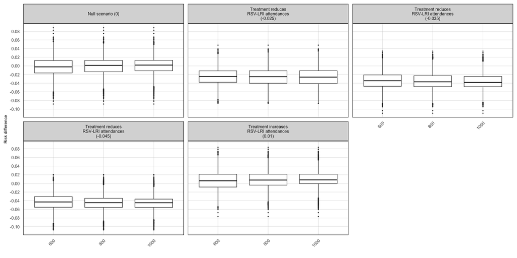

## Conclusion

- AD type-i assertion probability $\le$ 5%
- AD >80% power at 4.5% risk difference when assuming a baseline risk around 10%
- AD generally shorter in duration than fixed design
- AD will result in inconclusive result around 30% of time under null scenario
- AD more likely to conclude futility (lack of efficacy) than fixed design under all scenarios